# HW-03 - J Stewart

```r
library(gapminder)
library(tidyverse)
```

## GitHub Pages (6%) NEW

From now on, whenever you produce an HTML file output, you are expected to make it viewable as a webpage – for example, through GitHub Pages. There are / will be instructions added to the assignments home page on how to do this with GitHub Pages.

You should also provide links to these HTML pages in an easy-to-find location, and use words to describe what the link brings you to – probably in a README.md file in your hw03 folder Pick three of the six tasks below, and produce:

a tibble, using dplyr as your data manipulation tool; an accompanying plot of data from the tibble, using ggplot2 as your visualization tool; and some dialogue about what your tables/figures show (doesn’t have to be much).

Task Option 1 Report the absolute and/or relative abundance of countries with low life expectancy over time by continent: Compute some measure of worldwide life expectancy – you decide – a mean or median or some other quantile or perhaps your current age. Then determine how many countries on each continent have a life expectancy less than this benchmark, for each year.

```r
summary(gapminder)
```

```
##         country        continent        year         lifeExp
##  Afghanistan:  12   Africa  :624   Min.   :1952   Min.   :23.60
##  Albania    :  12   Americas:300   1st Qu.:1966   1st Qu.:48.20
##  Algeria    :  12   Asia    :396   Median :1980   Median :60.71
##  Angola     :  12   Europe  :360   Mean   :1980   Mean   :59.47
##  Argentina  :  12   Oceania : 24   3rd Qu.:1993   3rd Qu.:70.85
##  Australia  :  12                  Max.   :2007   Max.   :82.60
##  (Other)    :1632
##       pop              gdpPercap
##  Min.   :6.001e+04   Min.   :   241.2
##  1st Qu.:2.794e+06   1st Qu.:  1202.1
##  Median :7.024e+06   Median :  3531.8
##  Mean   :2.960e+07   Mean   :  7215.3
##  3rd Qu.:1.959e+07   3rd Qu.:  9325.5
##  Max.   :1.319e+09   Max.   :113523.1
##
```

## Task Option 2

*Maximum and minimum of GDP per capita for all continents.*

```r
gapminder %>%
  group_by(continent) %>%
  summarise (min_gdpPercap = min(gdpPercap),
            max_gdpPercap = max(gdpPercap))
```

```
## # A tibble: 5 x 3
##   continent min_gdpPercap max_gdpPercap
##   <fct>             <dbl>         <dbl>
## 1 Africa             241.        21951.
## 2 Americas          1202.        42952.
## 3 Asia               331        113523.
## 4 Europe             974.        49357.
## 5 Oceania          10040.        34435.
```

*Boxplot of GDP per capita for all continents.*

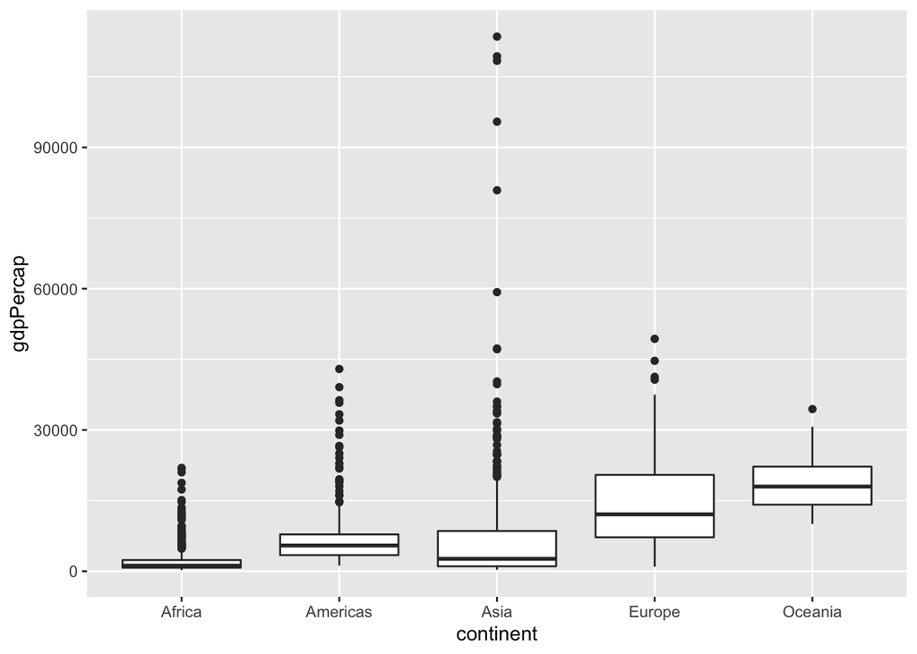

```r
ggplot(gapminder, aes(continent, gdpPercap)) +
  geom_boxplot()
```

## Task Option 3

**Spread of GDP per capita within the continents.**

```r
gapminder %>%
  group_by(continent) %>%
  summarise (Ave_gdpPercap = mean(gdpPercap))
```

```
## # A tibble: 5 x 2
##   continent Ave_gdpPercap
##   <fct>             <dbl>
## 1 Africa            2194.
## 2 Americas          7136.
## 3 Asia              7902.
## 4 Europe           14469.
## 5 Oceania          18622.
```

**Density plot of GDP per Capita by continent**

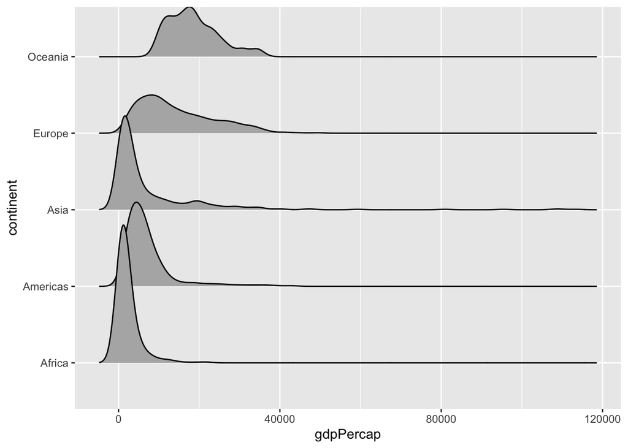

```r
ggplot(gapminder, aes(gdpPercap, continent)) +
  ggridges::geom_density_ridges()
```